# COVID-19 R0 Estimates

Rex W. Douglass

3/23/2020

# Introduction

```r
library(here)
```

This document attempts a very crude estimate of COVID-19 R0 using confirmed cases as a proxy for true cases, leveraging data across multiple countries to support a weighted median estimate.

```
[1] "Last updated  2020-03-23"
```

## Data on Count of Confirmed COVID-19 Cases

Data on confirmed case rate comes from [2019 Novel Coronavirus COVID-19 (2019-nCoV) Data Repository by Johns Hopkins CSSE](https://github.com/CSSEGISandData/COVID-19).

```r
library(tidyverse)
library(R0)  # consider moving all library commands to top -- this one was in a loop below
confirmed <- read_csv(url("https://raw.githubusercontent.com/CSSEGISandData/COVID-19/master/csse_covid_19_data/csse_covid_19_time_series/time_series_19-covid-Confirmed.csv"))
deaths <- read_csv(url("https://raw.githubusercontent.com/CSSEGISandData/COVID-19/master/csse_covid_19_data/csse_covid_19_time_series/time_series_19-covid-Deaths.csv"))
recovered <- read_csv(url("https://raw.githubusercontent.com/CSSEGISandData/COVID-19/master/csse_covid_19_data/csse_covid_19_time_series/time_series_19-covid-Recovered.csv"))

confirmed_long <- pivot_longer(confirmed, names_to = "date", cols = ends_with("20"), values_to = "confirmed")
deaths_long <- pivot_longer(deaths, names_to = "date", cols = ends_with("20"), values_to = "deaths")
recovered_long <- pivot_longer(recovered, names_to = "date", cols = ends_with("20"), values_to = "recovered")

library(lubridate)

all_long <- deaths_long %>%
  full_join(confirmed_long) %>%
  full_join(recovered_long) %>%
  filter(confirmed>0) %>%

  mutate(date_asdate = mdy(str_replace(date,"20$","2020"))) %>%
  rename(country=`Country/Region`, state=`Province/State`) %>%
  #filter(!state %in% c("From Diamond Princess","Diamond Princess")) %>%
  mutate(state=ifelse(is.na(state),"none",state)) %>%
  mutate(country_state=paste0(country, "___", state) %>% as.factor()  ) %>%

  arrange(country_state, date_asdate) %>%
  filter(confirmed>0) %>% #subset to only places/time periods that have had confirmed
  group_by(country_state) %>%
  mutate(days_since_1_confirmed=cumsum(confirmed>0)) %>%
  mutate(confirmed_fd=confirmed-lag(confirmed)) %>%

  ungroup() %>%
  filter(days_since_1_confirmed>0)

padded <- all_long %>%
          tidyr::expand(country_state, days_since_1_confirmed) %>%
          separate(col=country_state, into=c('country','state'), sep = "___", remove = T)

all_long <- padded %>%
            left_join(all_long) %>%
            arrange(country, state, days_since_1_confirmed) %>%
            mutate(country_state=paste0(country, "___", state) %>% as.factor()  )
```

Begin study periods on the date of the first reported confirmed COVID-19 case.

```r
library(DT)
all_long %>% dplyr::select(-country_state,-date_asdate) %>%
  head(1000) %>% #first 1000 rows
datatable(rownames = FALSE,
          options = list(
            pageLength = 10,
            columnDefs = list(list(className = 'dt-center', targets = "_all")
                              )
            )
)
```

| country | state | days_since_1_confirmed | Lat | Long | date | deaths | confirmed | recovered | confirmed_fd |
| --- | --- | --- | --- | --- | --- | --- | --- | --- | --- |
| Afghanistan | none | 1 | 33 | 65 | 2/24/20 | 0 | 1 | 0 |  |
| Afghanistan | none | 2 | 33 | 65 | 2/25/20 | 0 | 1 | 0 | 0 |
| Afghanistan | none | 3 | 33 | 65 | 2/26/20 | 0 | 1 | 0 | 0 |
| Afghanistan | none | 4 | 33 | 65 | 2/27/20 | 0 | 1 | 0 | 0 |
| Afghanistan | none | 5 | 33 | 65 | 2/28/20 | 0 | 1 | 0 | 0 |
| Afghanistan | none | 6 | 33 | 65 | 2/29/20 | 0 | 1 | 0 | 0 |
| Afghanistan | none | 7 | 33 | 65 | 3/1/20 | 0 | 1 | 0 | 0 |
| Afghanistan | none | 8 | 33 | 65 | 3/2/20 | 0 | 1 | 0 | 0 |
| Afghanistan | none | 9 | 33 | 65 | 3/3/20 | 0 | 1 | 0 | 0 |
| Afghanistan | none | 10 | 33 | 65 | 3/4/20 | 0 | 1 | 0 | 0 |

[output cut: 990 more lines]

## Population Data

Pull population data comes from wikidata.

```r
fromscratch=F
if(fromscratch){
  #We need to grab populations
  places <- all_long %>% dplyr::select(country,state) %>% distinct() %>% mutate(search=paste0(state,", ", country ))  %>% mutate(search= ifelse(is.na(state) | state=="none", country, state ) )
  library(WikidataR)
  wiki_searches <- list()
  for(q in places$search){
    print(q)
    try({
      #wiki <- find_item("Ramsey County")
      wiki <- find_item(q)
      temp <- as.data.frame(wiki[[1]])
      temp$search <- q
      wiki_searches[[q]] <- temp
    })
  }
  wiki_searches_df <- bind_rows(wiki_searches)

  item_df <- list()
  for(q in wiki_searches_df$id){
    print(q)
    try({
      item_df[[q]] <- get_item(id = q)
    })
  }
  wiki <- find_item("New York")

  latest_pop_list <- list()
  for(q in names(item_df)){
    print(q)
    try({
      latest_pop_list[[q]] <- data.frame(wikidata_id=q, P1082= rev(item_df[[q]][[1]]$claims$P1082$mainsnak$datavalue$value$amount)[1])
    })
  }
  latest_pop_df <- places %>% left_join(wiki_searches_df %>% dplyr::select(search,wikidata_id=id), by=c('search'='search')) %>% left_join( bind_rows(latest_pop_list) ) %>%
    mutate(population= str_replace(P1082,"\\+","") %>% as.numeric()    ) %>%
    mutate(population_log= log(population)) %>%
    mutate(state=ifelse(is.na(state),"none",state)) %>% distinct() %>% arrange(country, state)

  saveRDS(latest_pop_df,paste0(here::here(),"/data_in/latest_pop_df.RDS"))

}

latest_pop_df <- readRDS(paste0(here::here(), "/data_in/latest_pop_df.RDS"))

all_long_covariates <- all_long %>%
                       left_join(latest_pop_df) %>%
                       arrange(country, state, days_since_1_confirmed)
```

```r
library(DT)
latest_pop_df %>% dplyr::select(-search, -population_log) %>%
datatable(rownames = FALSE,
          options = list(
            pageLength = 10,
            columnDefs = list(list(className = 'dt-center', targets = "_all")
                              )
            )
)
```

| country | state | wikidata_id | P1082 | population |
| --- | --- | --- | --- | --- |
| Afghanistan | none | Q889 | +34940837 | 34940837 |
| Albania | none | Q222 | +2873457 | 2873457 |
| Algeria | none | Q262 | +41318142 | 41318142 |
| Andorra | none | Q228 | +76177 | 76177 |
| Angola | none | Q916 | +29784193 | 29784193 |
| Antigua and Barbuda | none | Q781 | +102012 | 102012 |
| Argentina | none | Q414 | +44938712 | 44938712 |
| Armenia | none | Q399 | +2930450 | 2930450 |
| Australia | Australian Capital Territory | Q3258 | +396857 | 396857 |
| Australia | From Diamond Princess |  |  |  |

[output cut: 388 more lines]

# Estimating R0

## Estimating with a log linear model

Experimenting with alternate estimation using epitrix packages.

https://www.repidemicsconsortium.org/epitrix/

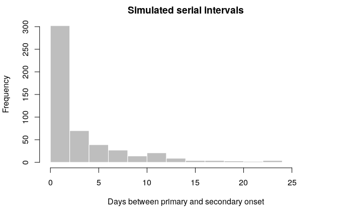

```r
library(epitrix) #install.packages("epitrix")

mu <- 3.96 #15.3 # mean in days days
sigma <- 4.75 #9.3 # standard deviation in days
cv <- sigma/mu # coefficient of variation
cv
param <- gamma_mucv2shapescale(mu, cv) # convertion to Gamma parameters
param
si <- distcrete::distcrete("gamma", interval = 1,
               shape = param$shape,
               scale = param$scale, w = 0)
si
set.seed(1)
x <- si$r(500)
head(x, 10)
hist(x, col = "grey", border = "white",
     xlab = "Days between primary and secondary onset",
     main = "Simulated serial intervals")
```

```r
si_fit <- fit_disc_gamma(x)
si_fit
library(outbreaks) #install.packages('outbreaks')
library(incidence) #install.packages('incidence')

locations <- all_long_covariates$country_state
r_log_linear_list <- list()
for(q in locations %>% unique() ){
  print(q)
  try({
    temp <- all_long_covariates %>% filter(country_state %in% q) %>% filter(!is.na(confirmed) )
    temp$confirmed_fd[1]<-temp$confirmed[1]

    incidents <- lapply(temp$days_since_1_confirmed[temp$confirmed_fd>0], FUN=function(x) { rep(temp$days_since_1_confirmed[x],temp$confirmed_fd[x]) } ) #print(x) ;
    incidents <- unlist( incidents )
    i <- incidence(incidents)
    i

    peak <- which(cummean(i$counts)==max(cummean(i$counts)))

    f <- fit(i[1:peak])  #fit the curve to the peak mean incidents
    plot(i, fit = f, color = "#9fc2fc")

    r_log_linear=r2R0(f$info$r, si$d(1:100))

    r_log_linear_list[[q]] <- data.frame(country=temp$country[1],state=temp$state[1], r_log_linear=round(r_log_linear,2 ))
  })
}
```

```r
r_log_linear_df <- bind_rows(r_log_linear_list)
```

## Estimating with the R0 package

A critical assumption is the serial interval of the disease. [Du et al. March 20, 2020](https://www.medrxiv.org/content/10.1101/2020.02.19.20025452v4) report a serial interval of 3.96 days with standard deviation of 4.75 days. Nishiura et al March 4, 2020 find a median of 4.0. [WHO’s literature review](https://www.who.int/docs/default-source/coronaviruse/situation-reports/20200219-sitrep-30-covid-19.pdf?sfvrsn=3346b04f_2) reports an incubation period of 5-6 days and serial interval from 4.4 to 7.5 days. Many simulations go with the early January 29, 2020 estimate from [Li et al.](https://www.nejm.org/doi/10.1056/NEJMoa2001316) of a mean serial interval of 7.5 days.

```r
#https://bmcmedinformdecismak.biomedcentral.com/articles/10.1186/1472-6947-12-147
#The generation time is the time lag between infection in a primary case and a secondary case. The generation time distribution should be obtained from the time lag between all infectee/infector pairs [8]. As it cannot be observed directly, it is often substituted with the serial interval distribution that measures time between symptoms onset. In our software package, the ‘generation.time’ function is used to represent a discretized generation time distribution. Discretization is carried out on the grid [0,0.5), [0.5, 1.5), [1.5, 2.5), etc.… where the unit is a user chosen time interval (hour, day, week…). Several descriptions are supported: “empirical” requiring the full specification of the distribution, or parametric distributions taken among “gamma”, “lognormal” or “weibull”. In the latter case, the mean and standard deviation must be provided in the desired time units.
library(R0)
mGT<-generation.time("gamma",
                     #Du et al. "The reported serial intervals range from -11 days to 20 days, with a mean of 3.96 days (95% confidence interval: 3.53-4.39), a standard deviation of 4.75 days (95% confidence interval: 4.46-5.07), "
                     val=c(
                       3.96,#Serial interval mean
                       4.75 #Serial interval standard deviation
                       ) #"val  Vector of values used for the empirical distribution, or c(mean, sd) if parametric."
                     )
```

R0 estimates generated with the R package [R0](https://cran.r-project.org/web/packages/R0/index.html)

“The R0 package: a toolbox to estimate reproduction numbers for epidemic outbreaks” [Obadia et al. 2012](https://bmcmedinformdecismak.biomedcentral.com/articles/10.1186/1472-6947-12-147)

```r
#Note many of these will throw errors for lack of data

locations <- all_long_covariates$country_state
r_R0_list <- list()
for(q in locations %>% unique() ){
  print(q)
  try({
    temp <- all_long_covariates %>% filter(country_state %in% q) %>% filter(!is.na(confirmed))
    temp$confirmed_fd[1]<-temp$confirmed[1]


    incidents <- as.vector(temp$confirmed_fd )
    pop <- temp$population[1]

    estR0<-est.R0.ML(
          epid=incidents,
          GT=mGT,
          begin=1,
          #end=length(incidents),
          methods="ML", #c("EG", "ML", "TD", "AR", "SB"),
          pop.size=pop, #Population size in which the incident cases were observed. See more details in est.R0.AR documentation
          impute.values=F #incidents[1]>10 #if the data start with more than 10 confirmed cases immediately then assume left censor and impute #imputation is really slow
    )
    #attributes(estR0)
    estR0
    r_R0_list[[q]] <- data.frame(country=temp$country[1],state=temp$state[1], r_ml=round(estR0$R,2), pop=pop, R2= round(estR0$Rsquared,2))
  })
}
```

```r
r_R0_df <- bind_rows(r_R0_list)
```

# Summary

Simple log linear model

```r
weights <- table(r_log_linear_df$country)
weights <- weights[r_log_linear_df$country]
weights <- 1/(weights/max(weights))
library(spatstat) #install.packages('spatstat')
print(results_log_linear <- r_log_linear_df %>% filter(!is.na(pop)) %>% pull(r_log_linear) %>% weighted.quantile(w=weights)) #weight by country, exclude obs with no population data.
```

```
  0%  25%  50%  75% 100%
0.91 1.48 1.64 1.85 5.42
```

```r
weights <- table(r_R0_df$country)
weights <- weights[r_R0_df$country]
weights <- 1/(weights/max(weights))

library(spatstat) #install.packages('spatstat')
print(results_R0 <- r_R0_df %>% filter(!is.na(pop)) %>% pull(r_ml) %>% weighted.quantile(w=weights)) #weight by country, exclude obs with no population data.
```

```
       0%       25%       50%       75%      100%
 1.250000  2.125815  2.560000  3.457194 31.620000
```

Distribution of R0 across locations.

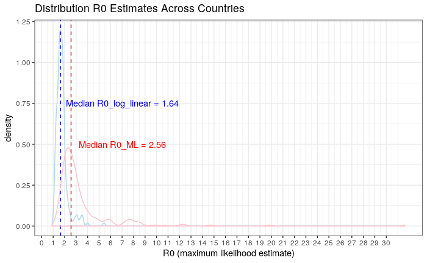

```r
r_estimates_all <- r_log_linear_df %>% full_join(r_R0_df)

r_estimates_all %>%
        filter(!is.na(pop)) %>%
        ggplot() +
        geom_density(aes(x=r_log_linear), col="lightblue") + geom_vline(xintercept = results_log_linear[3], stat = 'vline', linetype = "dashed", col="blue") +
        geom_density(aes(x=r_ml), col="pink") + geom_vline(xintercept = results_R0[3], stat = 'vline', linetype = "dashed", col="red") +
        ggtitle("Distribution R0 Estimates Across Countries") +
        theme_bw() +
        scale_x_continuous(breaks=seq(0, 30, by = 1)) +
        annotate("text", x = 7, y = .75, label = "Median R0_log_linear = 1.64", color="blue") +
        annotate("text", x = 7, y = .5, label = "Median R0_ML = 2.56", color="red") +
        xlab("R0 (maximum likelihood estimate)")
```

Raw Estimates

```r
library(DT)
r_estimates_all %>%
  mutate(r_ml= round(r_ml,2)) %>%
datatable(rownames = FALSE,
          options = list(
            pageLength = 50,
            columnDefs = list(list(className = 'dt-center', targets = "_all")
                              )
            )
)
```

| country | state | r_log_linear | r_ml | pop | R2 |
| --- | --- | --- | --- | --- | --- |
| Afghanistan | none | 1.26 | 2.03 | 34940837 | 0.1 |
| Albania | none | 2.19 | 1.57 | 2873457 | 0 |
| Algeria | none | 1.43 | 2.5 | 41318142 | 0.6 |
| Andorra | none | 1.6 | 31.62 | 76177 | 0.71 |
| Argentina | none | 1.68 | 2.42 | 44938712 | 0.79 |
| Armenia | none | 1.64 | 2.06 | 2930450 | 0.55 |
| Australia | Australian Capital Territory | 1.76 | 4.17 | 396857 | 0.84 |
| Australia | New South Wales | 1.27 | 1.97 | 6917658 | 0.7 |
| Australia | Queensland | 1.23 |  |  |  |
| Australia | South Australia | 1.2 | 2.49 | 1742744 | 0.68 |

[output cut: 253 more lines]

```r
NA
```